# Exponential Spatiotemporal GARCH Model with Asymmetric Volatility Spillovers

Author

Ariane N. Meli Chrisko, Philipp Otto, Wolfgang Schmid

## Exponential Spatiotemporal GARCH Model with Asymmetric Volatility Spillovers

## Abstract

A spatiotemporal exponential generalised autoregressive conditional heteroscedasticity (spatiotemporal E-GARCH) model is introduced here, extending traditional spatiotemporal GARCH models by incorporating asymmetric volatility spillovers, while also generalising the time-series E-GARCH model to a spatiotemporal setting with instantaneous, potentially asymmetric volatility spillovers across space. The model allows for both temporal and spatial dependencies in volatility dynamics, capturing how financial shocks propagate across time, space, and network structures. We establish the theoretical properties of the model, deriving stationarity conditions and moment existence results. We propose a quasi-maximum likelihood (QML) estimator for estimation and assess their finite-sample performance through Monte Carlo simulations. Empirically, we apply the model to financial networks, specifically analysing volatility spillovers in stock markets. We compare different network structures and analyse asymmetric effects in instantaneous volatility interactions.

## The Model

Let $\mathbf{s}_1, \cdots, \mathbf{s}_n$ denote the spatial locations, and let $\mathbf{Y}_t$ be the vector of observations at time $t$, defined as $\mathbf{Y}_t = \left(Y_t(\mathbf{s}_1), \ldots, Y_t(\mathbf{s}_n)\right)^\top$. We specify the outcome equation of a spatiotemporal EGARCH(1,1) model as follows:

$$\begin{eqnarray} \mathbf{Y}_t &=& \text{diag}(\mathbf{h}_t)^{1/2} , \boldsymbol{\varepsilon}_t \label{eq:initial} \ \ln \mathbf{h}_t &=& \alpha_1 + \rho_0 \mathbf{W}_1 g(\boldsymbol{\varepsilon}_t) + \rho_1 g(\boldsymbol{\varepsilon}_{t-1}) + \lambda_0 \mathbf{W}_2 \ln \mathbf{h}_t + \lambda_1 \ln \mathbf{h}_{t-1}
\end{eqnarray}$$

Here, $\mathbf{h}_t = \left(h_t(\mathbf{s}_1), \ldots, h_t(\mathbf{s}_n)\right)^\top$ is the vector of conditional variances, and $\boldsymbol{\varepsilon}_t = \left(\varepsilon_t(\mathbf{s}_1), \ldots, \varepsilon_t(\mathbf{s}_n)\right)^\top$ denotes the innovation terms, assumed to be independent and identically distributed with mean zero and constant variance. The term $\ln \mathbf{h}_t$ is applied element-wise. The asymmetric innovation effect is captured by the function

$$\begin{equation} g(\boldsymbol{\varepsilon}_t) = \Theta \boldsymbol{\varepsilon}_t + \xi \left(|\boldsymbol{\varepsilon}_t| - \mathbb{E}|\boldsymbol{\varepsilon}_t|\right).
\end{equation}$$

The full parameter vector is given by $\boldsymbol{\vartheta} = \left(\alpha_1, \rho_0, \rho_1, \lambda_0, \lambda_1, \Theta, \xi\right)^\top$. In this specification, $\rho_0 \mathbf{W}_1 g(\boldsymbol{\varepsilon}_t)$ captures spatial asymmetric effects, while $\rho_1 g(\boldsymbol{\varepsilon}_{t-1})$ accounts for temporal asymmetric effects. The parameters $\lambda_0$ and $\lambda_1$ describe the spatial and temporal dependence in the log-volatility process, respectively. The parameter $\Theta$ governs the response of volatility to shocks, and $\xi$ captures the leverage effect through the absolute innovation adjustment.

## Required packages

Below, we load different packages needed

```r
library("rio")
library("BatchGetSymbols")
library("cluster")
library("TSclust")
library("lgarch")
library("MASS")
library("doParallel")
library(ggplot2)
library(reshape2)
library(Rsolnp)
library(classInt)
library(nleqslv)
library(Matrix)
library("igraph")
library("wesanderson")
library(spdep)  # Load required package for spatial weights
library(MTS)
library(gplots)
library(rugarch)
library(gridExtra)
library(dplyr)
```

## Function for simulation

**Show function for simulation**

```r
simulate_spatiotemporal_EGARCH <- function(params, T, burnin, n, W_1, W_2) {

  # Check that weight matrices are provided and have correct dimensions
  if (is.null(W_1) || is.null(W_2)) {
    stop("You must provide both spatial weight matrices W_1 and W_2.")
  }

  if (nrow(W_1) != n || ncol(W_1) != n) {
    stop("W_1 must be an n x n matrix.")
  }

  if (nrow(W_2) != n || ncol(W_2) != n) {
    stop("W_2 must be an n x n matrix.")
  }


  # Extract parameters from the list (single theta)
  rho_0    <- params$rho_0      # Spatial impact for current period
  rho_1    <- params$rho_1      # Impact for lagged shocks
  theta    <- params$theta      # Single theta parameter
  alpha    <- params$alpha      # Constant term in volatility
  xi       <- params$xi         # Coefficient for absolute error adjustment
  lambda_0 <- params$lambda_0   # Spatial dependence in log-volatility
  lambda_1 <- params$lambda_1   # Temporal dependence in log-volatility
  Dist     <- params$errortype  # Error distribution


  # Total number of time periods (including burn-in)
  total_T <- burnin + T


  # Preallocate matrix for innovations
  eps <- matrix(NA, n, total_T)


  # ============================================================
  # Error distributions
  # ============================================================

  if (Dist == "norm") {

    # Standard normal innovations:
    # E(epsilon) = 0, Var(epsilon) = 1

    mean_abs_eps <- sqrt(2 / pi)

    for (t in 1:total_T) {
      eps[, t] <- rnorm(n)
    }


  } else if (Dist == "t") {

    # Degrees of freedom
    df <- 3

    # Standardization factor for Student-t:
    # if X ~ t_df, then
    # epsilon = X * sqrt((df - 2) / df)
    # has variance 1.

    scale_t <- sqrt((df - 2) / df)

    for (t in 1:total_T) {
      eps[, t] <- rt(n, df = df) * scale_t
    }


    # E|epsilon| for standardized Student-t
    mean_abs_eps <-
      scale_t *
      (2 * sqrt(df) * gamma((df + 1) / 2)) /
      ((df - 1) * sqrt(pi) * gamma(df / 2))


  } else {

    stop("errortype must be either 'norm' or 't'.")

  }


  # ============================================================
  # Compute transformed errors
  #
  # g(epsilon) =
  # theta * epsilon +
  # xi * (|epsilon| - E|epsilon|)
  # ============================================================

  geps <- matrix(NA, n, total_T)

  for (t in 1:total_T) {

    geps[, t] <-
      theta * eps[, t] +
      xi * (abs(eps[, t]) - mean_abs_eps)

  }


  # ============================================================
  # Initial innovation for the lagged shock term
  # ============================================================

  if (Dist == "norm") {

    eps0 <- rnorm(n)

  } else if (Dist == "t") {

    # Use the same standardized Student-t distribution
    eps0 <- rt(n, df = df) * scale_t

  }


  # Important: use the SAME eps0 in both components of g(eps0)

  geps0_init <- as.numeric(
    theta * eps0 +
      xi * (abs(eps0) - mean_abs_eps)
  )


  # ============================================================
  # Preallocate log-volatility and observations
  # ============================================================

  lnh <- matrix(NA, n, total_T)
  Y_out <- matrix(NA, n, total_T)


  # Initial log-volatility
  #
  # The distribution of the innovations does not imply that
  # the initial log-volatility has the same distribution.
  # Burn-in reduces dependence on this initialization.

  lnh_0 <- rnorm(n)


  # ============================================================
  # Spatial adjustment matrix  S = (I - lambda_0 W_2)^(-1)
  # ============================================================

  S <- solve(diag(n) - lambda_0 * W_2)


  # ============================================================
  # Simulation loop
  # ============================================================

  for (t in 1:total_T) {

    if (t == 1) {

      lnh[, t] <- as.numeric(
        S %*% (lambda_1 * lnh_0) +
          S %*% rep(alpha, n) +
          S %*% (rho_0 * W_1) %*% geps[, t] +
          S %*% (rho_1 * geps0_init)
      )

    } else {

      lnh[, t] <- as.numeric(
        S %*% (lambda_1 * lnh[, t - 1]) +
          S %*% rep(alpha, n) +
          S %*% (rho_0 * W_1) %*% geps[, t] +
          S %*% (rho_1 * geps[, t - 1])
      )

    }


    # Y_t = sqrt(h_t) * epsilon_t
    Y_out[, t] <- sqrt(exp(lnh[, t])) * eps[, t]

  }


  # ============================================================
  # Remove burn-in period
  # ============================================================

  Y_final   <- Y_out[, -(1:burnin)]
  lnh_final <- lnh[, -(1:burnin)]
  eps_final <- eps[, -(1:burnin)]


  # Return simulation output
  return(
    list(
      Y = Y_final,
      lnh = lnh_final,
      eps = eps_final,
      params = params
    )
  )
}
```

## Usage of the simulation function

```r
# Create spatial weight matrices (5x5 grid, using rook contiguity)
d <- 5
n <- d^2
W_1 <- nb2mat(cell2nb(d, d, type = "rook"))
W_2 <- nb2mat(cell2nb(d, d, type = "queen"))

# Define simulation settings
T_sim  <- 200  # Number of time periods after burn-in
burnin <- 50   # Burn-in period

# Define parameter list
params <- list(
  rho_0    = 0.25,
  rho_1    = 0.3,
  theta    = -0.5,
  alpha    = 0.5,
  xi       = 1,
  lambda_0 = 0.35,
  lambda_1 = 0.4,
  errortype = "norm"
)

# Run the simulation
steSimu <- simulate_spatiotemporal_EGARCH(params = params, T = T_sim, burnin = burnin, n = n, W_1 = W_1, W_2 = W_2)

# Check dimensions of the simulated outcome
print(dim(steSimu$Y))  # Expected: 25 x 200
```

```
[1]  25 200
```

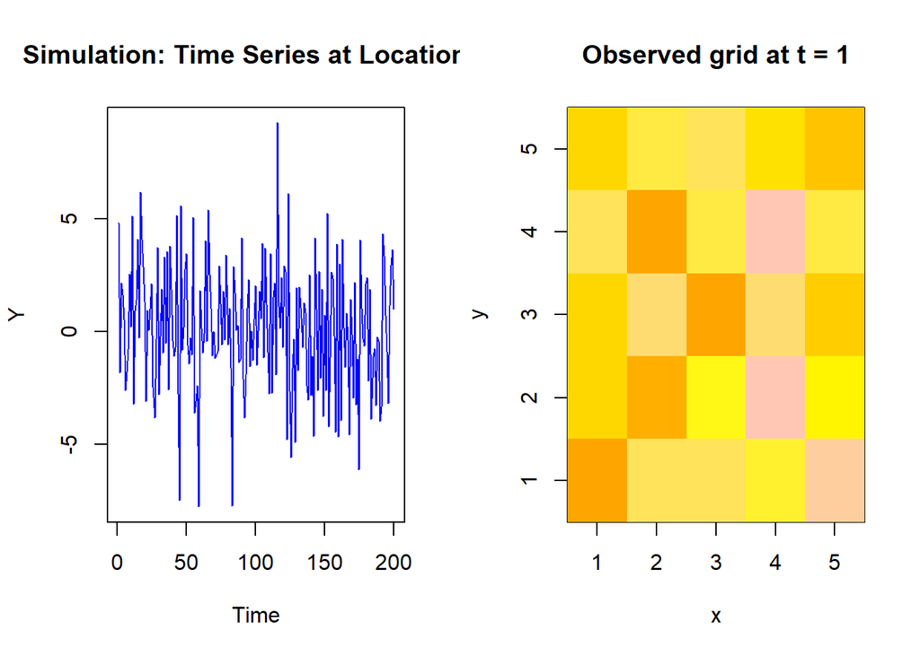

```r
#visualisation

colours <- colorpanel(20, "pink", "yellow", "orange")
colbreaks <- classIntervals(steSimu$Y, n = length(colours), style = "quantile")

par(mfcol = c(1, 2))

# Plot the simulated time series for the first spatial location
plot(steSimu$Y[1, ], type = "l", col = "blue",
     main = "Simulation: Time Series at Location 1",
     xlab = "Time", ylab = "Y")

# Plot the observed lattice for the first time period (t = 1)
image(1:d, 1:d, array(steSimu$Y[, 1], dim = c(d, d)),
      col = colours, breaks = colbreaks$brks,
      main = "Observed grid at t = 1",
      xlab = "x", ylab = "y")
```

## Evaluating temporal asymmetry in simulated data

**Show function for Egarch**

```r
#  Define EGARCH(1,1) model specification
spec_egarch <- ugarchspec(
  variance.model = list(model = "eGARCH", garchOrder = c(1,1)),
  mean.model = list(armaOrder = c(0,0)),
  distribution.model = "std"  # Student-t for heavy tails
)

#  Function to fit EGARCH and extract asymmetry parameter (gamma1) and its p-value
fit_egarch <- function(series) {
  result <- tryCatch({
    fit <- suppressWarnings(ugarchfit(spec = spec_egarch, data = series))
    gamma <- coef(fit)["gamma1"]
    p_value <- fit@fit$matcoef["gamma1", 4]
    c(Gamma = as.numeric(gamma), P_Value = as.numeric(p_value))
  }, error = function(e) c(Gamma = NA_real_, P_Value = NA_real_))
  return(result)
}
```

```r
Datar_numeric <- t(steSimu$Y)

#  Apply the function to each asset (column of Datar_numeric)
results_list <- lapply(1:ncol(Datar_numeric), function(i) fit_egarch(Datar_numeric[, i]))

# Combine the results into a clean data frame
egarch_results <- as.data.frame(do.call(rbind, results_list))
colnames(egarch_results) <- c("Gamma", "P_Value")
rownames(egarch_results) <- colnames(Datar_numeric)  # Optional: label by asset name

#  Count the number of assets with significant asymmetry (p < 0.05)
asymmetric_count <- sum(egarch_results$P_Value < 0.05, na.rm = TRUE)

# Display results
#print(egarch_results)
cat("Number of series with significant asymmetry (p < 0.05):", asymmetric_count, "\n")
```

```
Number of series with significant asymmetry (p < 0.05): 16
```

## Numerical invertibility of the Model

The innovations $(\varepsilon_t)$ are unobservable, and only the observed process $(\textbf{Y}_t)$ is available. Since the likelihood function is expressed in terms of the innovations, parameter estimation requires recovering $(\varepsilon_t)$ numerically. To avoid identification issues, we set $\xi = 1$. Using data generated from our simulation function, the innovations are estimated recursively by solving the system of equations below, where the innovation estimate $\tilde{\varepsilon}_{t, \vartheta}$ is computed for a given parameter vector $\vartheta$:
$$\begin{eqnarray}
& (I& - \lambda_0 W_2) \ln \tilde{\varepsilon}_{t, \vartheta}^2 + \rho_0 W_1 g( \tilde{\varepsilon}_{t, \vartheta}) \; - \nonumber \\
& \quad &\left((I - \lambda_0 W_2) \ln Y_t^2 - \alpha - \rho_1 g( \tilde{\varepsilon}_{t-1, \vartheta}) - \lambda_1 \ln Y_{t-1}^2 + \lambda_1 \ln \tilde{\varepsilon}_{t-1, \vartheta}^2 \right) = 0.
\end{eqnarray}$$
We initialise the recursion with $Y_0(s) = 0.0001$ and $\varepsilon_0(s) = 0.0001$ for all spatial locations $s$, and assume $E|\varepsilon_t|$ equals the expected value of a standard normal distribution. At each time point $t$, the system is solved using the solver. This numerical inversion must be repeated for every parameter vector $\vartheta$ during the likelihood maximisation.

**Show function for invertibility**

```r
#########################################################
## INVERSION FUNCTION g
## SINGLE THETA
########################################################

invert_g <- function(
    y,
    alpha,
    rhoW_1,
    lambdaW_2,
    rho_1,
    lambda_1,
    theta,
    xi,
    eps_lag,
    Y_lag) {

  n <- length(y)

  ## Expected absolute value of a standard normal innovation
  mean_abs_eps <- sqrt(2 / pi)
  xi<- 1

  ## --------------------------------------------------------
  ## Solve in z = log(|epsilon|)
  ## This guarantees |epsilon| > 0 and preserves sign(y)
  ## --------------------------------------------------------

  function_z <- function(
      z,
      y,
      alpha,
      rhoW_1,
      lambdaW_2,
      rho_1,
      lambda_1,
      theta,
      xi) {

    sign_y <- ifelse(
      y >= 0,
      1,
      -1
    )

    eps <- sign_y * exp(z)

    return(
      (diag(n) - lambdaW_2) %*%
        log(pmax(abs(y)^2, 1e-16)) -

        ( rep(alpha, n) +

            ## Contemporaneous network shock effect
            rhoW_1 %*%
            (
              theta * eps +
                xi *
                (
                  abs(eps) -
                    mean_abs_eps
                )
            ) +

            ## Lagged own-stock shock effect
            ## SAME theta is used here
            rho_1 *
            (
              theta * eps_lag +
                xi *
                (
                  abs(eps_lag) -
                    mean_abs_eps
                )
            ) +

            ## Temporal log-volatility effect
            lambda_1 *
            (
              log(
                pmax(
                  abs(Y_lag)^2,
                  1e-16
                )
              ) -
                log(
                  pmax(
                    abs(eps_lag)^2,
                    1e-16
                  )
                )
            ) +

            ## Contemporaneous network log-volatility
            (diag(n) - lambdaW_2) %*%
            log(
              pmax(
                abs(eps)^2,
                1e-16
              )
            )
        )
    )
  }


  ## --------------------------------------------------------
  ## Starting values: epsilon approximately equal to y
  ## --------------------------------------------------------

  z0 <- log(
    pmax(
      abs(y),
      1e-8
    )
  )


  ## --------------------------------------------------------
  ## Numerical inversion
  ## --------------------------------------------------------

  out <- tryCatch(

    nleqslv(
      x = z0,
      fn = function_z,

      y = y,
      alpha = alpha,
      rhoW_1 = rhoW_1,
      lambdaW_2 = lambdaW_2,
      rho_1 = rho_1,
      lambda_1 = lambda_1,
      theta = theta,
      xi = xi,

      control = list(
        ftol = 1e-10
      )
    ),

    error = function(e) NULL
  )


  ## --------------------------------------------------------
  ## Check numerical solution
  ## --------------------------------------------------------

  if (is.null(out)) {
    return(NULL)
  }

  if (!(out$termcd %in% c(1, 2))) {
    return(NULL)
  }

  max_residual <- max(
    abs(out$fvec)
  )

  if (
    !is.finite(max_residual) ||
      max_residual > 1e-8
  ) {
    return(NULL)
  }


  ## --------------------------------------------------------
  ## Recover epsilon with correct sign
  ## --------------------------------------------------------

  eps <- sign(y) * exp(out$x)


  ## --------------------------------------------------------
  ## Recover log-volatility
  ## y_t = sqrt(h_t) epsilon_t therefore
  ## log(h_t) = log(y_t^2) - log(epsilon_t^2)
  ## --------------------------------------------------------

  lnh <-
    log(
      pmax(
        abs(y)^2,
        1e-16
      )
    ) -
    log(
      pmax(
        abs(eps)^2,
        1e-16
      )
    )


  ## --------------------------------------------------------
  ## Final checks
  ## --------------------------------------------------------

  if (length(eps) != length(y)) {
    stop("epsilon length mismatch")
  }


  return(
    list(
      eps = eps,
      lnh = lnh,
      convergence = out$termcd,
      residual = max_residual
    )
  )
}
```

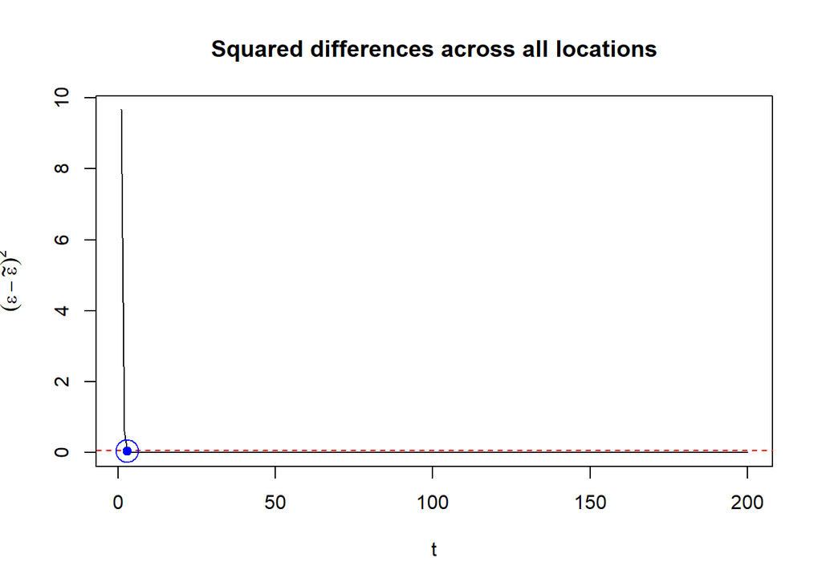

```r
# Extract simulation output and parameters
Y <- steSimu$Y         # Simulated outcomes (n x T)
eps_true <- steSimu$eps  # True innovations (n x T)
params <- steSimu$params

alpha    <- params$alpha
rho_0    <- params$rho_0
rho_1    <- params$rho_1
theta    <- params$theta
xi       <- params$xi
lambda_0 <- params$lambda_0
lambda_1 <- params$lambda_1

# Determine dimensions
T <- ncol(Y)  # Number of time periods (post burnin)
n <- nrow(Y)  # Number of spatial locations

# Preallocate matrices for estimated latent errors and log-volatility
lnh_hat <- matrix(NA, n, T)
eps_hat <- matrix(NA, n, T)
diff_squared <- matrix(NA, n, T)

# Loop over time periods to invert the mapping and recover eps and log-volatility

for (t in 1:T) {
  if(t == 1){
    out <- invert_g(Y[, t], alpha = alpha, rhoW_1 = rho_0 * W_1, lambdaW_2 = lambda_0 * W_2, theta = theta, xi = xi, rho_1 = rho_1, lambda_1 = lambda_1,
             eps_lag = rep(0.01, length(Y[, t])), Y_lag = rep(0.01, length(Y[, t])))
  } else {
    out <- invert_g(Y[, t], alpha = alpha, rhoW_1 = rho_0 * W_1, lambdaW_2 = lambda_0 * W_2, theta = theta, xi = xi, rho_1 = rho_1, lambda_1 = lambda_1,
             eps_lag = eps_hat[,t-1], Y_lag = Y[,t-1])
  }
  eps_hat[,t] <- out$eps
  lnh_hat[,t] <- out$lnh
  diff_squared[, t] <- (eps_hat[, t] - eps_true[, t])^2
}

# Identify the first time point where the maximum of (eps - eps_hat)^2 across all locations is less than 0.05
time_point <- which(apply(diff_squared, 2, max) < 0.05)[1]

# Plot the difference (eps - eps_hat)^2 over time
plot(1:T, apply(diff_squared, 2, max), type = "l", xlab = "t", ylab = expression((epsilon - tilde(epsilon))^2), main = "Squared differences across all locations")
abline(h = 0.05, col = "red", lty = 2) # Add a horizontal line at 0.05
points(time_point, max(diff_squared[, time_point]), col = "blue", pch = 19) # Mark the time point where (eps - eps_hat)^2 becomes less than 0.05
symbols(time_point, max(diff_squared[, time_point]), circles = 0.5, inches = 0.1, add = TRUE, fg = "blue")
```

### Evaluating the inverse function

Thus, an efficient solver such as the solver is important for a good computational performance. Below, we first focus on the differences between $\tilde{\varepsilon_t}$ and $\varepsilon_t$ for the true data-generating parameters $\vartheta_0$ for each time point $t$. Secondly, we analyse the same differences but for parameters $\vartheta$ away from $\vartheta_0$ to show that the differences are, indeed, minimised at $\vartheta = \vartheta_0$.

**Show functions needed for invertibility**

```r
pairing_params_plot <- function(param1_name, param2_name, param_grids, true_params) {
  param1_grid <- param_grids[[param1_name]]
  param2_grid <- param_grids[[param2_name]]


  results <- data.frame(param1 = double(), param2 = double(), A = double(), B = double())

  for (param1 in param1_grid) {
    for (param2 in param2_grid) {
      lnh_hat <- array(NA, dim = c(n, T))
      eps_hat <- array(NA, dim = c(n, T))
      for (t in 1:T) {
        current_params <- true_params
        current_params[[param1_name]] <- param1
        current_params[[param2_name]] <- param2

        if (t == 1) {
          out <- invert_g(Y[, t],
                   alpha = current_params$alpha,
                   rhoW_1 = current_params$rho_0 * W_1,
                   lambdaW_2 = current_params$lambda_0 * W_2,
                   theta = current_params$theta,
                   xi = current_params$xi,
                   rho_1 = current_params$rho_1,
                   lambda_1 = current_params$lambda_1,
                   eps_lag = rep(0.0001, length(Y[, t])),
                   Y_lag = rep(0.0001, length(Y[, t])))
        } else {
          out <- invert_g(Y[, t],
                   alpha = current_params$alpha,
                   rhoW_1 = current_params$rho_0 * W_1,
                   lambdaW_2 = current_params$lambda_0 * W_2,
                   theta = current_params$theta,
                   xi = current_params$xi,
                   rho_1 = current_params$rho_1,
                   lambda_1 = current_params$lambda_1,
                   eps_lag = eps_hat[, t - 1],
                   Y_lag = Y[, t - 1])
        }
        eps_hat[, t] <- out$eps
        lnh_hat[, t] <- out$lnh
      }

      A <- sum((eps_hat - eps_true)^2)
      B <- sum((eps_hat[, -(1:5)] - eps_true[, -(1:5)])^2)

      results <- rbind(results, data.frame(param1 = param1, param2 = param2, A = round(A, 3), B = round(B, 3)))
    }
  }

  colnames(results)[1:2] <- c(param1_name, param2_name)
  param1_breaks <- c(param1_grid[1], true_params[[param1_name]], param1_grid[length(param1_grid)])
  param2_breaks <- c(param2_grid[1], true_params[[param2_name]], param2_grid[length(param2_grid)])


  param1_label <- switch(param1_name,
                         alpha = expression(alpha),
                         rho_0 = expression(rho[0]),
                         rho_1 = expression(rho[1]),
                         lambda_0 = expression(lambda[0]),
                         lambda_1 = expression(lambda[1]),
                         theta = expression(theta),
                         param1_name)  # Fallback to the name itself if no match

  param2_label <- switch(param2_name,
                         alpha = expression(alpha),
                         rho_0 = expression(rho[0]),
                         rho_1 = expression(rho[1]),
                         lambda_0 = expression(lambda[0]),
                         lambda_1 = expression(lambda[1]),
                         theta = expression(theta),
                         param2_name)  # Fallback to the name itself if no match


  # Plotting B or A
  p1 <- ggplot(results, aes(x = .data[[param1_name]], y = .data[[param2_name]], fill = .data[["B"]])) +
    geom_tile() +
    scale_fill_gradient(name = NULL,low = "white", high = "grey") +
    geom_vline(xintercept = true_params[[param1_name]], linetype = "dashed", color = "green") +
    geom_hline(yintercept = true_params[[param2_name]], linetype = "dashed", color = "green") +
    #ggtitle(paste("Variation of B with", param1_name, "and", param2_name)) +
    theme_minimal()+

    theme(
      aspect.ratio = 1,
      legend.key.size = unit(0.9, "lines"),  # Adjust the size of the legend
      legend.text = element_text(size = 9),  # Adjust the size of the legend text
      #axis.title.x = element_blank(),
      #axis.title.y = element_blank()
    ) +
    scale_x_continuous(breaks = param1_breaks) +
    scale_y_continuous(breaks = param2_breaks) +
    #scale_x_continuous(breaks = true_params[[param1_name]]) +
    #scale_y_continuous(breaks = true_params[[param2_name]]) +
    guides(fill = guide_colorbar(keywidth = 0.5, keyheight = 2)) +
    labs(x = param1_label, y = param2_label)  # Set axis labels

  return(p1)
}


# Generating all possible pairs of parameters
generate_param_pairs <- function(param_names) {
  param_pairs <- list()
  k <- length(param_names)
  for (i in 1:(k-1)) {
    for (j in (i+1):k) {
      param_pairs <- append(param_pairs, list(c(param_names[i], param_names[j])))
    }
  }
  return(param_pairs)
}
```

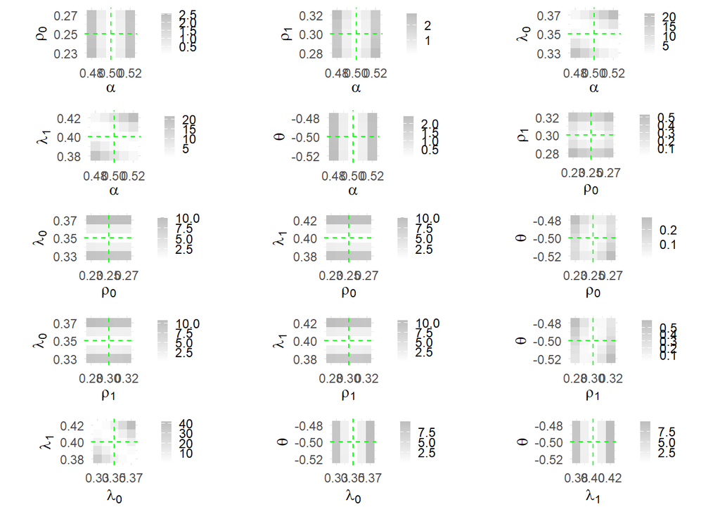

```r
# Defining parameter grids

param_grids <- list(
  alpha = seq(alpha-0.02, alpha+0.02, by=0.01 ),
  rho_0 = seq(rho_0-0.02, rho_0+0.02, by = 0.01),
  rho_1 = seq(rho_1-0.02, rho_1+0.02, by = 0.01),
  lambda_0 = seq(lambda_0-0.02, lambda_0+0.02, by = 0.01),
  lambda_1 = seq(lambda_1-0.02, lambda_1+0.02, by = 0.01),
  theta = seq(theta-0.02, theta+0.02, by = 0.01)
  #xi = seq(xi-0.02, xi+0.02, by = 0.01)
)


# Defining the list of true_params
true_params <- list(alpha = alpha, rho_0 = rho_0, rho_1 = rho_1, lambda_0 = lambda_0, lambda_1 = lambda_1, theta = theta)

# generating pairs
param_names <- c("alpha", "rho_0", "rho_1", "lambda_0", "lambda_1", "theta")
param_pairs <- generate_param_pairs(param_names)



# Initialize an empty list to store all the plots
all_plots <- list()

# Iterate over each parameter pair
for (pair in param_pairs) {
  param1 <- pair[1]
  param2 <- pair[2]
  #cat("Processing pair:", param1, "vs", param2, "\n")

  # Create a plot for the current parameter pair
  current_plot <- pairing_params_plot(param1, param2, param_grids, true_params)

  # Store the plot in the list
  all_plots[[paste(param1, "vs", param2)]] <- current_plot
}


# Combine all plots in a grid layout with 7 rows and 3 columns
combined_plot <- grid.arrange(grobs = all_plots, nrow = 5, ncol = 3)
```

```r
#print(combined_plot)
```

## Procedure for Maximum Likelihood Estimation

In the following section, we focus on estimating the parameter vector $\vartheta = (\alpha, \rho_0, \rho_1, \lambda_0, \lambda_1, \Theta, \xi)'$. For identification purposes, we fix $\xi = 1$. The maximum likelihood estimation relies on the previously defined numerical mapping from the observed process $\mathbf{Y}_t$ to the unobserved innovations $\mathbf{\varepsilon}_t$.

**Show estimation function**

```r
estimate_EGARCH <- function(Y, W_1, W_2, initial_params, silent = TRUE) {

  # ============================================================
  # Input checks
  # ============================================================

  if (is.null(Y)) {
    stop("Y is missing")
  }

  if (is.null(W_1) || is.null(W_2)) {
    stop("Both W_1 and W_2 are required")
  }

  if (!all(dim(W_1) == dim(W_2))) {
    stop("W_1 and W_2 must have the same dimensions")
  }

  n <- nrow(Y)
  T_periods <- ncol(Y)


  # ============================================================
  # IMPORTANT:
  # Keep Y on its ORIGINAL scale.
  #
  # Do NOT use:
  # Y <- log(Y^2)
  #
  # invert_g() performs the required log(Y^2) transformation
  # internally.
  # ============================================================


  # ============================================================
  # DERIVATIVE dh / d epsilon
  # SINGLE THETA
  # ============================================================

  d_h_d_eps <- function(
      eps,
      h,
      theta,
      xi,
      rhoW_1,
      lambdaW_2) {

    n <- length(eps)

    # (I - lambda_0 W_2)^(-1) rho_0 W_1
    A <- solve(
      diag(n) - lambdaW_2,
      rhoW_1
    )

    # Derivative of
    # g(eps) = theta * eps + xi * (|eps| - E|eps|)
    gprime <- theta + xi * sign(eps)

    # d log(h) / d eps
    Dlogh <- sweep(
      A,
      2,
      gprime,
      `*`
    )

    # d h / d eps
    Dh <- sweep(
      Dlogh,
      1,
      h,
      `*`
    )

    return(Dh)
  }


  # ============================================================
  # LIKELIHOOD
  # SINGLE THETA
  # ============================================================

  likelihood <- function(params, Y, W_1, W_2) {

    # ----------------------------------------------------------
    # Parameters
    # ----------------------------------------------------------

    rho_0    <- params[1]
    rho_1    <- params[2]
    theta    <- params[3]
    alpha    <- params[4]
    lambda_1 <- params[5]
    lambda_0 <- params[6]

    xi <- 1

    n <- nrow(Y)
    T_periods <- ncol(Y)

    eps_hat <- matrix(
      0.01,
      nrow = n,
      ncol = T_periods
    )

    log_det_J <- numeric(T_periods)


    # ----------------------------------------------------------
    # Matrix constant over time
    #
    # A = (I - lambda_0 W_2)^(-1) rho_0 W_1
    # ----------------------------------------------------------

    A <- tryCatch(
      solve(
        diag(n) - lambda_0 * W_2,
        rho_0 * W_1
      ),
      error = function(e) NULL
    )

    if (is.null(A) || any(!is.finite(A))) {
      return(1e8)
    }


    # ----------------------------------------------------------
    # Invert observations period by period
    # ----------------------------------------------------------

    for (t in seq_len(T_periods)) {

      if (t == 1) {

        out <- invert_g(
          Y[, t],

          alpha = alpha,
          rhoW_1 = rho_0 * W_1,
          lambdaW_2 = lambda_0 * W_2,

          rho_1 = rho_1,
          lambda_1 = lambda_1,

          theta = theta,
          xi = xi,

          eps_lag = rep(0.001, n),
          Y_lag = rep(0.001, n)
        )

      } else {

        out <- invert_g(
          Y[, t],

          alpha = alpha,
          rhoW_1 = rho_0 * W_1,
          lambdaW_2 = lambda_0 * W_2,

          rho_1 = rho_1,
          lambda_1 = lambda_1,

          theta = theta,
          xi = xi,

          eps_lag = eps_hat[, t - 1],
          Y_lag = Y[, t - 1]
        )
      }


      # --------------------------------------------------------
      # Failed inversion
      # --------------------------------------------------------

      if (is.null(out)) {
        return(1e8)
      }

      if (
        length(out$eps) != n ||
        any(!is.finite(out$eps)) ||
        any(!is.finite(out$lnh))
      ) {
        return(1e8)
      }


      eps_hat[, t] <- out$eps


      # --------------------------------------------------------
      # Jacobian
      # --------------------------------------------------------

      gprime <- theta + xi * sign(out$eps)

      Dlogh <- sweep(
        A,
        2,
        gprime,
        `*`
      )

      M <- diag(n) +
        0.5 * diag(out$eps) %*% Dlogh


      det_M <- tryCatch(
        determinant(
          M,
          logarithm = TRUE
        ),
        error = function(e) NULL
      )


      if (
        is.null(det_M) ||
        det_M$sign == 0 ||
        !is.finite(as.numeric(det_M$modulus))
      ) {
        return(1e8)
      }


      log_det_J[t] <-
        0.5 * sum(out$lnh) +
        as.numeric(det_M$modulus)
    }


    # ----------------------------------------------------------
    # Gaussian log-likelihood
    # Remove first five periods
    # ----------------------------------------------------------

    likelihood_value <-
      sum(
        dnorm(
          eps_hat[, -(1:5), drop = FALSE],
          log = TRUE
        )
      ) -
      sum(
        log_det_J[-(1:5)]
      )


    if (!is.finite(likelihood_value)) {
      return(1e8)
    }


    # Negative log-likelihood
    return(-likelihood_value)
  }


  # ============================================================
  # Parameter bounds
  # ============================================================

  # Parameter order:
  # rho_0, rho_1, theta, alpha, lambda_1, lambda_0

  LB <- c(
    0.0001,   # rho_0
    0.0001,   # rho_1
    -0.99,    # theta
    -10,      # alpha
    0.0001,   # lambda_1
    0.0001    # lambda_0
  )

  UB <- c(
    0.99,             # rho_0
    0.999999999999,   # rho_1
    0.999,            # theta
    100,              # alpha
    0.99,             # lambda_1
    0.99               # lambda_0
  )


  # ============================================================
  # Estimation
  # ============================================================

  resultll <- solnp(
    pars = initial_params,
    fun = likelihood,
    LB = LB,
    UB = UB,
    control = list(
      trace = ifelse(silent, 0, 1)
    ),
    Y = Y,
    W_1 = W_1,
    W_2 = W_2
  )


  # ============================================================
  # Extract results
  # ============================================================

  est_params <- resultll$pars

  names(est_params) <- c(
    "rho_0",
    "rho_1",
    "theta",
    "alpha",
    "lambda_1",
    "lambda_0"
  )

  k <- length(est_params)
  nObs <- nrow(Y) * ncol(Y)

  logLik_opt <-
    -resultll$values[length(resultll$values)]

  AIC <-
    2 * k -
    2 * logLik_opt

  BIC <-
    log(nObs) * k -
    2 * logLik_opt


  # ============================================================
  # Compute estimated innovations and volatility
  # ============================================================

  eps_hat <- matrix(
    0.01,
    nrow = n,
    ncol = T_periods
  )

  h_hat <- matrix(
    0.01,
    nrow = n,
    ncol = T_periods
  )


  for (t in seq_len(T_periods)) {

    if (t == 1) {

      out <- invert_g(
        Y[, t],

        alpha = est_params[4],
        rhoW_1 = est_params[1] * W_1,
        lambdaW_2 = est_params[6] * W_2,

        rho_1 = est_params[2],
        lambda_1 = est_params[5],

        theta = est_params[3],
        xi = 1,

        eps_lag = rep(0.001, n),
        Y_lag = rep(0.001, n)
      )

    } else {

      out <- invert_g(
        Y[, t],

        alpha = est_params[4],
        rhoW_1 = est_params[1] * W_1,
        lambdaW_2 = est_params[6] * W_2,

        rho_1 = est_params[2],
        lambda_1 = est_params[5],

        theta = est_params[3],
        xi = 1,

        eps_lag = eps_hat[, t - 1],
        Y_lag = Y[, t - 1]
      )
    }


    if (is.null(out)) {
      stop(
        paste(
          "Inversion failed when computing fitted values at t =",
          t
        )
      )
    }


    eps_hat[, t] <- out$eps

    # IMPORTANT correction:
    h_hat[, t] <- exp(out$lnh)
  }


  # ============================================================
  # Return
  # ============================================================

  return(
    list(
      estimated_params = est_params,
      logLik = logLik_opt,
      AIC = AIC,
      BIC = BIC,
      eps_hat = eps_hat,
      h_hat = h_hat,
      result = resultll
    )
  )
}
```

```r
# ---- Example Usage ----


# Set initial parameters
initial_params <- c(
  rho_0 = 0.15,
  rho_1 = 0.23,
  theta = 0.02,
  alpha = sd(Y),
  lambda_1 = 0.11,
  lambda_0 = 0.25
)

# Run estimation
result_est <- estimate_EGARCH(Y, W_1, W_2, initial_params, silent = "TRUE")

# Print results
print(result_est$estimated_params)
```

```
     rho_0      rho_1      theta      alpha   lambda_1   lambda_0
 0.2976197  0.2840135 -0.5143845  0.5752325  0.4062630  0.3069084
```

```r
print(result_est$AIC)
```

```
[1] 23781.18
```

## Mini Monte Carlo simulation study

```r
# Settings
r <- 25                      # Number of Monte Carlo replications
d <- 5                       # Grid dimension
n <- d^2                     # Total locations
T <- 100                     # Time series length
burnin <- 10                 # Burn-in period

# Spatial weights
W_1 <- nb2mat(cell2nb(d, d, type = "queen"))
W_2 <- nb2mat(cell2nb(d, d, type = "rook"))

# True parameters as a named list
true_params <- list(
  rho_0 = 0.5,
  rho_1 = 0.35,
  theta = 0.4,
  alpha = 0.5,
  xi = 1,
  lambda_1 = 0.3,
  lambda_0 = 0.2,
  errortype = "norm"
)

param_names <- c("rho_0", "rho_1", "theta", "alpha", "lambda_1", "lambda_0")
results_matrix <- matrix(NA, nrow = r, ncol = length(param_names))
colnames(results_matrix) <- param_names

# Monte Carlo loop
for (i in 1:r) {
  #cat("Replication", i, "\n")
  # Simulate data
  sim <- simulate_spatiotemporal_EGARCH(
    params = true_params, T = T, burnin = burnin, n = n,
    W_1 = W_1, W_2 = W_2
  )

  Y_sim <- sim$Y

  # Estimate model
  est_result <- tryCatch(
    estimate_EGARCH(Y = Y_sim, W_1 = W_1, W_2 = W_2, initial_params = unlist(true_params[param_names]), silent = TRUE),
    error = function(e) {
      warning(paste("Estimation failed at iteration", i))
      return(NULL)
    }
  )

  if (!is.null(est_result)) {
    results_matrix[i, ] <- est_result$estimated_params
  }
}

# Convert to data frame
results_df <- as.data.frame(results_matrix)
results_df$Replication <- 1:r
results_long <- melt(results_df, id.vars = "Replication", variable.name = "Param", value.name = "Estimate")
results_long$True <- rep(unlist(true_params[param_names]), each = r)

# Summary table
summary_table <- results_long %>%
  group_by(Param) %>%
  summarise(
    True_Value = unique(True),
    Mean_Estimate = mean(Estimate, na.rm = TRUE),
    Bias = round(mean(Estimate - True, na.rm = TRUE), 4),
    RMSE = round(sqrt(mean((Estimate - True)^2, na.rm = TRUE)), 4),
    Std_Dev = round(sd(Estimate, na.rm = TRUE), 4)
  )

# Output
print(summary_table)
```

```
# A tibble: 6 × 6
  Param    True_Value Mean_Estimate    Bias   RMSE Std_Dev
  <fct>         <dbl>         <dbl>   <dbl>  <dbl>   <dbl>
1 rho_0          0.5          0.502  0.0017 0.0701  0.0715
2 rho_1          0.35         0.355  0.0054 0.0485  0.0492
3 theta          0.4          0.418  0.018  0.0964  0.0967
4 alpha          0.5          0.530  0.0303 0.0953  0.0923
5 lambda_1       0.3          0.283 -0.0173 0.0855  0.0855
6 lambda_0       0.2          0.186 -0.0139 0.0944  0.0953
```